# Chapter6

esoini

2022-12-08

# Analysis of longitudinal data

Loading the data

```r
library(tidyverse)
dat1<-read.csv("./data/BPRS.csv")
dat2<-read.csv("./data/rats.csv")
dat2og<-read.table("https://raw.githubusercontent.com/KimmoVehkalahti/MABS/master/Examples/data/rats.txt",sep = "\t",header = T)

#changing to factors
dat1<-dat1 %>% mutate(treatment=as.factor(treatment)) %>%
  mutate(subject= as.factor(subject)) %>%
  mutate(id=as.factor(id))
dat2<-dat2 %>% mutate(ID=as.factor(ID)) %>%
  mutate(Group=as.factor(Group))

#dat1 <-  dat1 %>% mutate(week = as.integer(substr(weeks,5,5)))
#dat2 <-  dat2 %>% mutate(time = as.integer(substr(time,3,3)))
```

Dat2 has data on 16 rats that were put on different diet. Their weight (in grams) was measured for 9 weeks.

First I will visualize the data

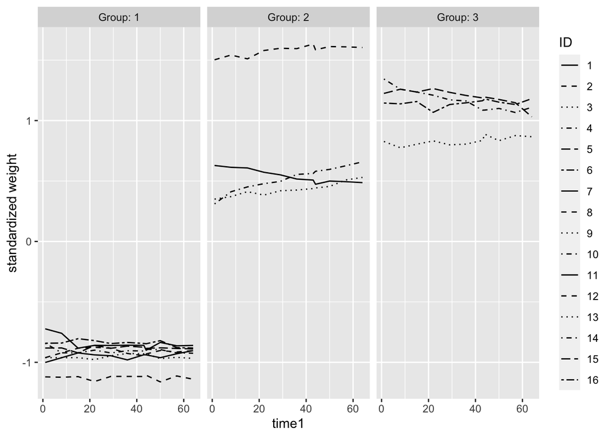

```r
dat2 <- dat2 %>%
    group_by(time1) %>%
  mutate( stdweight = (weight - mean(weight))/sd(weight) ) %>%
  ungroup()

# Plot again with the standardised weight
library(ggplot2)
ggplot(dat2, aes(x = time1, y = stdweight, linetype = ID)) +
  geom_line() +
  scale_linetype_manual(values = rep(1:10, times=4)) +
  facet_grid(. ~ Group, labeller = label_both) +
  scale_y_continuous(name = "standardized weight")
```

```r
dat22 <- dat2 %>%
  filter(time1>1) %>%
  group_by(Group, time1) %>%
  summarise( mean = mean(weight), se = sd(weight)/sqrt(16) ) %>%
  ungroup()
```

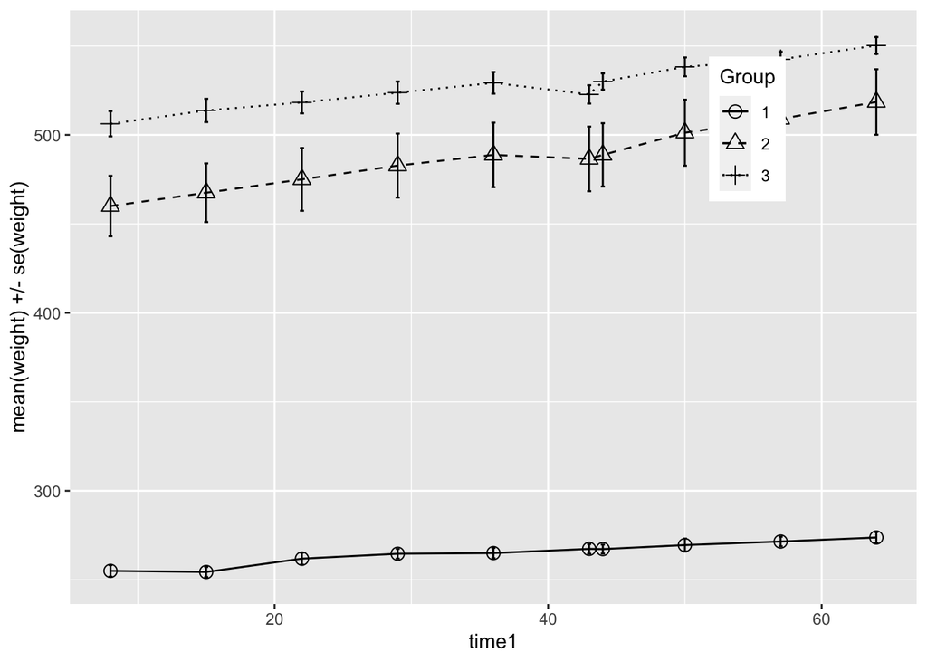

```r
ggplot(dat22, aes(x = time1, y = mean, linetype = Group, shape = Group)) +
  geom_line() +
  scale_linetype_manual(values = c(1,2,3)) +
  geom_point(size=3) +
  scale_shape_manual(values = c(1,2,3)) +
  geom_errorbar(aes(ymin=mean-se, ymax=mean+se, linetype="1"), width=0.3) +
  theme(legend.position = c(0.8,0.8)) +
  scale_y_continuous(name = "mean(weight) +/- se(weight)")
```

```r
dat22 <- dat2 %>%
  filter(time1>1) %>%
  group_by(Group, ID) %>%
  summarise( mean = mean(weight), se = sd(weight)/sqrt(16) ) %>%
  ungroup()
```

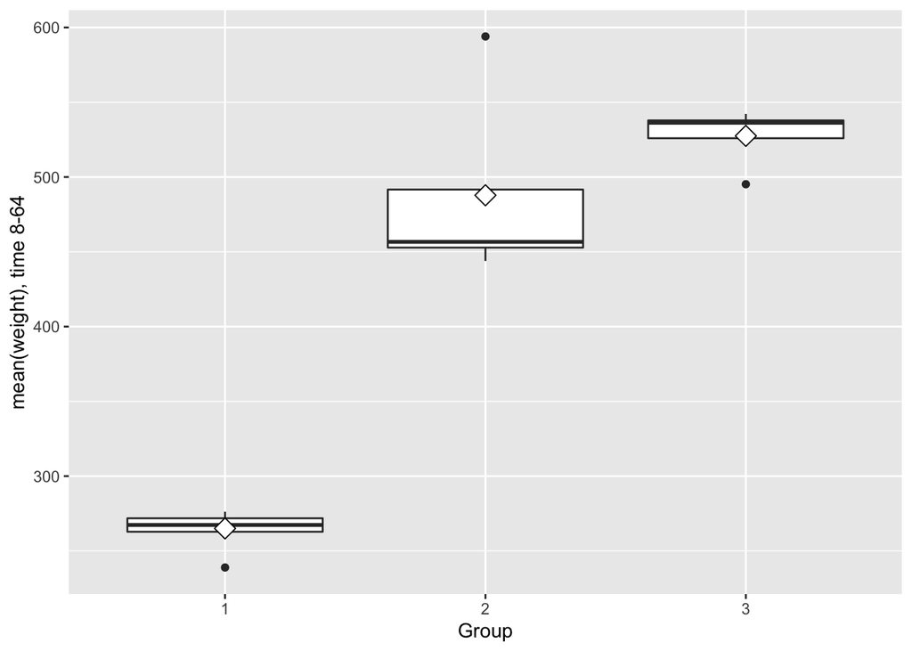

```r
ggplot(dat22, aes(x = Group, y = mean)) +
  geom_boxplot() +
  stat_summary(fun = "mean", geom = "point", shape=23, size=4, fill = "white") +
  scale_y_continuous(name = "mean(weight), time 8-64")
```

Lets conduct anova to test the differences. Though according the plots groups 2 and three differ from group1.

```r
dat3 <- dat2 %>%
  filter(time1 > 1) %>%
  group_by(Group,ID) %>%
  summarise( mean=mean(weight) ) %>%
  ungroup()
dat3 <- dat3 %>%
  mutate(baseline = dat2og$WD1)

# Fit the linear model with the mean as the response
fit <- lm(mean~baseline+Group, data = dat3)

# Compute the analysis of variance table for the fitted model with anova()
anova(fit)
```

```
## Analysis of Variance Table
##
## Response: mean
##           Df Sum Sq Mean Sq   F value   Pr(>F)
## baseline   1 253625  253625 1859.8201 1.57e-14 ***
## Group      2    879     439    3.2219  0.07586 .
## Residuals 12   1636     136
## ---
## Signif. codes:  0 '***' 0.001 '**' 0.01 '*' 0.05 '.' 0.1 ' ' 1
```

Groups are close to statistical signifigance. Baseline seems to predict mean well, and groups did not differ from each other.

I will do contrast to checj if group 1 differs from other groups

```r
dat4<-dat3 %>% mutate(group1=ifelse(Group==1,1,2))
fit2 <- lm(mean~baseline+group1, data = dat4)

# Compute the analysis of variance table for the fitted model with anova()
anova(fit2)
```

```
## Analysis of Variance Table
##
## Response: mean
##           Df Sum Sq Mean Sq   F value    Pr(>F)
## baseline   1 253625  253625 1806.5913 2.448e-15 ***
## group1     1    690     690    4.9159   0.04505 *
## Residuals 13   1825     140
## ---
## Signif. codes:  0 '***' 0.001 '**' 0.01 '*' 0.05 '.' 0.1 ' ' 1
```

If we combine group 2 and 3, they seem to differ from group 1 at alpha-level .05. As the analysis was done ad-hoc, it should not be interpreted as hypothesis testing, but rather as exploring the data.

Dat1 has data on 40 male subjects were randomly assigned to one of two treatment groups and each subject was rated on the brief psychiatric rating scale (BPRS) measured before treatment (week 0) and follow-up data waws collected weekly for 8 weeks. The BPRS is used to evaluate patients suspected of having schizophrenia.

Standardizing the data and drawing plots

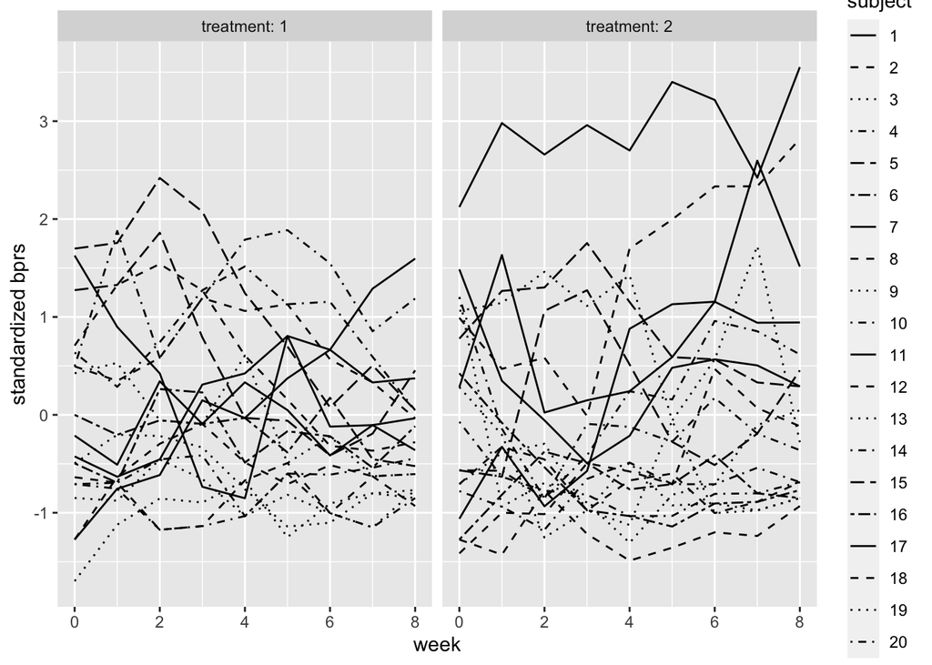

```r
dat1 <- dat1 %>%
    group_by(week) %>%
  mutate( stdbprs = (bprs - mean(bprs))/sd(bprs) ) %>%
  ungroup()

# Plot again with the standardised bprs
library(ggplot2)
ggplot(dat1, aes(x = week, y = stdbprs, linetype = subject)) +
  geom_line() +
  scale_linetype_manual(values = rep(1:10, times=4)) +
  facet_grid(. ~ treatment, labeller = label_both) +
  scale_y_continuous(name = "standardized bprs")
```

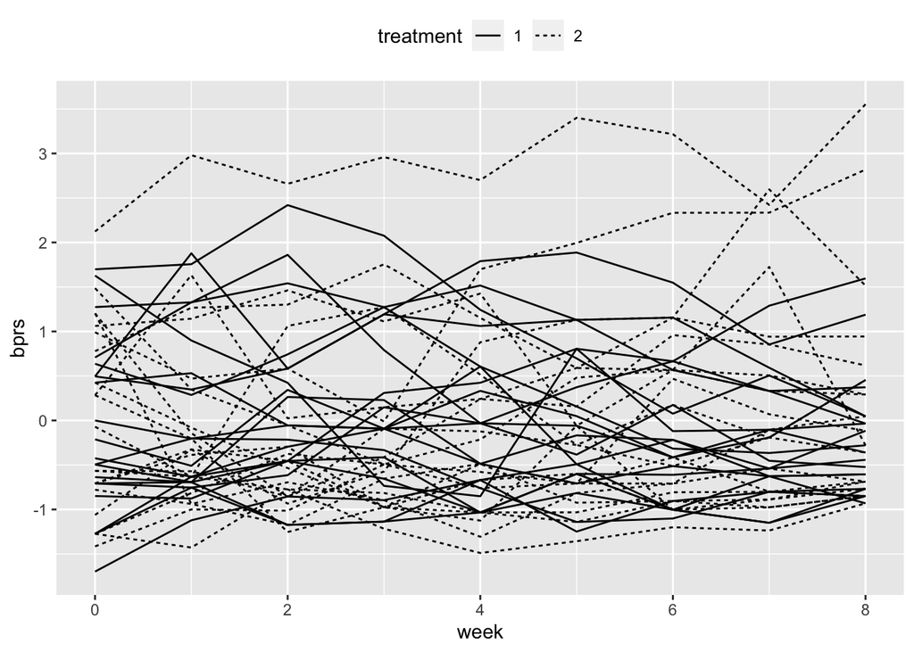

```r
dat11<-dat1%>% arrange(week)

ggplot(dat11, aes(x = week, y = stdbprs, group = id)) +
  geom_line(aes(linetype=treatment))+
  scale_y_continuous(name = "bprs")+
  theme(legend.position = "top")
```

Standardized bprs scores do not seem to differ greatly between groups. ##Regression

Next I fit regression to the data, in a stepwise manner. First a regular linear regression that does not take into account that data has multiplle observation from each of the participants, ie. we cannot assume that the observation are independnt of each others, but clustered within participants. Next I fit a model with that has a random intercept to account for the correlations within individual, so that intercept is allowed to vary between participants. LAstly in this section I will fit random intercept random slope model in, in addition to intercept, also slope is allowed to vary by participant.

```r
# create a regression model RATS_reg
reg <- lm(bprs~ week+treatment, data = dat1)

# print out a summary of the model
summary(reg)
```

```
##
## Call:
## lm(formula = bprs ~ week + treatment, data = dat1)
##
## Residuals:
##     Min      1Q  Median      3Q     Max
## -22.454  -8.965  -3.196   7.002  50.244
##
## Coefficients:
##             Estimate Std. Error t value Pr(>|t|)
## (Intercept)  46.4539     1.3670  33.982   <2e-16 ***
## week         -2.2704     0.2524  -8.995   <2e-16 ***
## treatment2    0.5722     1.3034   0.439    0.661
## ---
## Signif. codes:  0 '***' 0.001 '**' 0.01 '*' 0.05 '.' 0.1 ' ' 1
##
## Residual standard error: 12.37 on 357 degrees of freedom
## Multiple R-squared:  0.1851, Adjusted R-squared:  0.1806
## F-statistic: 40.55 on 2 and 357 DF,  p-value: < 2.2e-16
```

```r
library(lme4)
# Create a random intercept model
ref <- lmer(bprs ~ week + treatment + (1 | subject), data = dat1, REML = FALSE)

# Print the summary of the model
summary(ref)
```

```
## Linear mixed model fit by maximum likelihood  ['lmerMod']
## Formula: bprs ~ week + treatment + (1 | subject)
##    Data: dat1
##
##      AIC      BIC   logLik deviance df.resid
##   2748.7   2768.1  -1369.4   2738.7      355
##
## Scaled residuals:
##     Min      1Q  Median      3Q     Max
## -3.0481 -0.6749 -0.1361  0.4813  3.4855
##
## Random effects:
##  Groups   Name        Variance Std.Dev.
##  subject  (Intercept)  47.41    6.885
##  Residual             104.21   10.208
## Number of obs: 360, groups:  subject, 20
##
## Fixed effects:
##             Estimate Std. Error t value
## (Intercept)  46.4539     1.9090  24.334
## week         -2.2704     0.2084 -10.896
## treatment2    0.5722     1.0761   0.532
##
## Correlation of Fixed Effects:
##            (Intr) week
## week       -0.437
## treatment2 -0.282  0.000
```

```r
ref1 <- lmer(bprs ~ week + treatment + (week | subject), data = dat1, REML = FALSE)

# print a summary of the model
summary(ref1)
```

```
## Linear mixed model fit by maximum likelihood  ['lmerMod']
## Formula: bprs ~ week + treatment + (week | subject)
##    Data: dat1
##
##      AIC      BIC   logLik deviance df.resid
##   2745.4   2772.6  -1365.7   2731.4      353
##
## Scaled residuals:
##     Min      1Q  Median      3Q     Max
## -2.8919 -0.6194 -0.0691  0.5531  3.7976
##
## Random effects:
##  Groups   Name        Variance Std.Dev. Corr
##  subject  (Intercept) 64.8222  8.0512
##           week         0.9609  0.9802   -0.51
##  Residual             97.4305  9.8707
## Number of obs: 360, groups:  subject, 20
##
## Fixed effects:
##             Estimate Std. Error t value
## (Intercept)  46.4539     2.1052  22.066
## week         -2.2704     0.2977  -7.626
## treatment2    0.5722     1.0405   0.550
##
## Correlation of Fixed Effects:
##            (Intr) week
## week       -0.582
## treatment2 -0.247  0.000
```

```r
# perform an ANOVA test on the two models
anova(ref1, ref)
```

```
## Data: dat1
## Models:
## ref: bprs ~ week + treatment + (1 | subject)
## ref1: bprs ~ week + treatment + (week | subject)
##      npar    AIC    BIC  logLik deviance  Chisq Df Pr(>Chisq)
## ref     5 2748.7 2768.1 -1369.4   2738.7
## ref1    7 2745.4 2772.6 -1365.7   2731.4 7.2721  2    0.02636 *
## ---
## Signif. codes:  0 '***' 0.001 '**' 0.01 '*' 0.05 '.' 0.1 ' ' 1
```

Random intercept reduces the error of the model compared to regular regression. According to anova, the model with random intercept and random slope fits the data better at alpha level =.05 . This means that ref1 explains more variation in the data compared to ref.

Lastly, I will fit a model that allows interaction between week and treatment

```r
ref2 <- lmer(bprs ~ week + treatment + (week | subject) + (week*treatment), data = dat1, REML = FALSE)
summary(ref2)
```

```
## Linear mixed model fit by maximum likelihood  ['lmerMod']
## Formula: bprs ~ week + treatment + (week | subject) + (week * treatment)
##    Data: dat1
##
##      AIC      BIC   logLik deviance df.resid
##   2744.3   2775.4  -1364.1   2728.3      352
##
## Scaled residuals:
##     Min      1Q  Median      3Q     Max
## -3.0513 -0.6271 -0.0768  0.5288  3.9260
##
## Random effects:
##  Groups   Name        Variance Std.Dev. Corr
##  subject  (Intercept) 65.0048  8.0626
##           week         0.9687  0.9842   -0.51
##  Residual             96.4702  9.8219
## Number of obs: 360, groups:  subject, 20
##
## Fixed effects:
##                 Estimate Std. Error t value
## (Intercept)      47.8856     2.2522  21.262
## week             -2.6283     0.3589  -7.323
## treatment2       -2.2911     1.9090  -1.200
## week:treatment2   0.7158     0.4010   1.785
##
## Correlation of Fixed Effects:
##             (Intr) week   trtmn2
## week        -0.650
## treatment2  -0.424  0.469
## wek:trtmnt2  0.356 -0.559 -0.840
```

```r
anova(ref2,ref1)
```

```
## Data: dat1
## Models:
## ref1: bprs ~ week + treatment + (week | subject)
## ref2: bprs ~ week + treatment + (week | subject) + (week * treatment)
##      npar    AIC    BIC  logLik deviance  Chisq Df Pr(>Chisq)
## ref1    7 2745.4 2772.6 -1365.7   2731.4
## ref2    8 2744.3 2775.4 -1364.1   2728.3 3.1712  1    0.07495 .
## ---
## Signif. codes:  0 '***' 0.001 '**' 0.01 '*' 0.05 '.' 0.1 ' ' 1
```

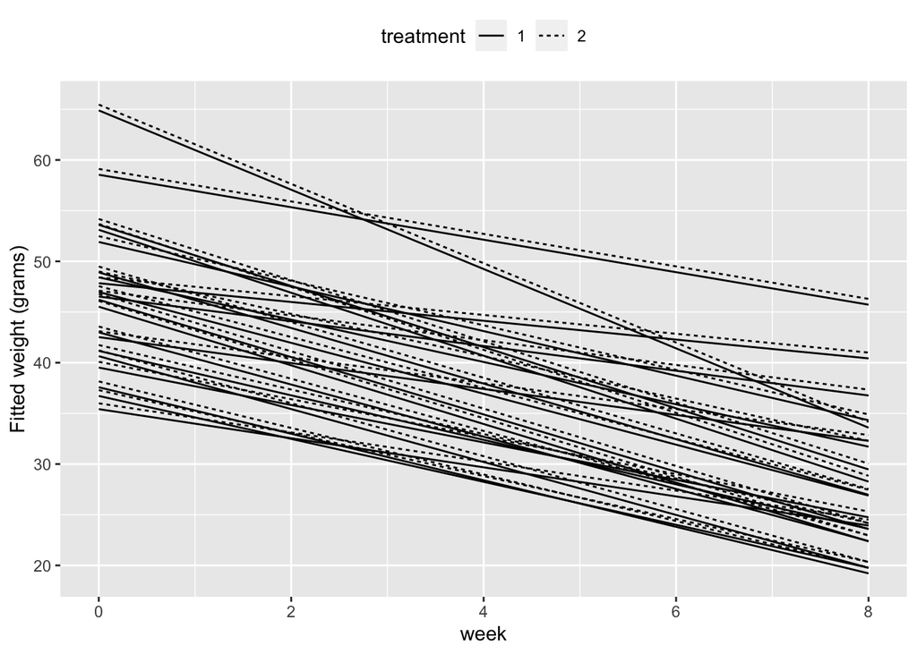

```r
Fitted <- fitted(ref1)
dat1$fitted<-Fitted

# draw the plot of RATSL with the Fitted values of weight

ggplot(dat1, aes(x = week, y = fitted, group= id)) +
  geom_line(aes(linetype=treatment))+
  scale_x_continuous(name = "week", breaks = seq(0, 10, 2)) +
  scale_y_continuous(name = "Fitted weight (grams)") +
  theme(legend.position = "top")
```

Model that allows interaction between week and treatment does not improve the fit at alpha level = .05. When looking at the results from ref1, ( model with random intercepts and random slopes) the two groups do not seem to differ from each other. We dont know if the other group was control group or did they compare two different treatments, so all we can say is that the treatments do not differ between their effect on bprs. All the participants showed a linear trend, with weeks being associated with lower scores on bprs.